# Linear Regression: Group 3

Author

Milo Klein, Shane Egerstrom, Tammy Lee, Brooke Comstock

# Introduction

## Hypothesized relationship

For the relationship between per-capita GDP growth and per-capita CO2 emissions, we predict that there will be generally a positive correlation between the two variables. It should be pointed out that we are using CO2 emissions as the response variable and GDP as the explanatory variable.

## Methods

### The Data

The CO2 emissions data was taken from the Global Carbon Project, CDAIC and other sources. It documents the change in CO2 emissions produced by each country from 1800-2022. (https://docs.google.com/spreadsheets/d/1t_GOXGrXQgSasIB7dWfRrq9dkqjrqwy3xHvywH7ah1A/edit#gid=501532268). Originally, our CO2 emission data had 194 rows (Countries) and 224 columns (1800:2022). After pivoting longer, there were 43,262 rows (CO2 observations) and 3 columns (country, year, CO2).

For the GDP data, this was taken from multiple sources depending on the date range. From 1990 to 2019, data from the World Bank was primarily used, while from before 1990 was taken from Maddison Project Database and Penn World Table of the Groningen Growth and Development Centre. In summary, this data documents the change in GDP for most countries between years 1800 and 2100 (https://www.gapminder.org/data/geo/changes/). Furthermore, the data originally had 195 rows (Countries) and 302 columns (individual years, 1800:2100). After pivot: 58,695 rows (GDP observations) and 3 columns (country, year, GDP).

### **Data Cleaning Process and Cecisions**

After importing both data sets, we cleaned each by making sure all years were numeric and ready to merge. GDP values represented by characters such as “10k” were changed to numeric values. We also eliminated an “X” character from each of the years in the Emissions data set that prevented merging. Then, we pivoted both and conducted a full merge by “Year” and “Country”. Finally, we began filtering by years of interest. Future projections (years past 2021) were not considered in our data.

```r
library(gapminder)
library(gganimate)
library(tidyverse)
library(patchwork)
library(broom)
library(kableExtra)
library(gifski)

GDP <- read_csv("gdp_pcap.csv")
Emissions <- read_csv("co2_pcap_cons.csv")
```

```r
Emissions_clean <- Emissions |>
  select(`country`:`2022`)|>
  mutate(across(everything(), ~ str_replace(., "−", "-")))|>
  filter(across(everything(), ~is.na(.) == 0)) |>
  mutate_at(vars(`1800`:`2022`), as.numeric)|>
  pivot_longer(cols = `1800`:`2022`,
               names_to = "Year",
               values_to = "CO2")
```

```r
GDP_clean <- GDP |>
  select(`country`:`2022`)|>
  mutate(across(`1800`:`2022`,
                  ~case_when(is.character(.) & str_detect(., "k") ~ as.numeric(str_replace(., "k", "")) * 1000,
                             TRUE ~ as.numeric(.)))) |>
  pivot_longer(cols = `1800`:`2022`,
               names_to ="Year", values_to = "GDP")
```

```r
merged_data <- full_join(GDP_clean,
                         Emissions_clean,
                         by = c("country", "Year")) |>
               mutate(Year = as.numeric(Year))
```

## Results

**GDP, CO2 Emissions, and Decades Visualizations**

There are multiple ways to model the relationship between GDP and CO2. However, a great factor in the increase of CO2 emissions is the beginning of the Industrial Revolution, with some countries starting as early as the 19th century.

A linear regression model looks at one explanatory/independent variable and see how it affects the values of one response/dependent variable. A “linear” regression specifically implies that changes in the explanatory will cause changes to the dependent variable at a fixed function increment, creating “line.” Some linear regression models may also account for the data “noise” to account for random variation or error between the independent and dependent variables, while others may be fitted, where the function would have to estimate values.

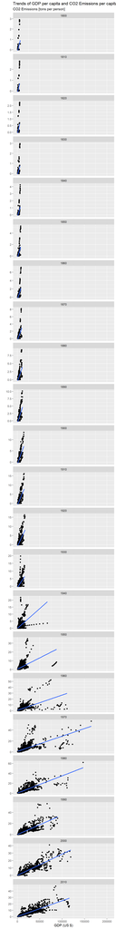

```r
#1: Visual exploring the relationship between the two quantitative variables changing over time

# Create a new variable for decade
filtered_data_decade <- merged_data |>
  mutate(decade = (10*(Year %/% 10))) |>
  filter(decade %in% 1800:2019) |>
  group_by(country, decade, Year)|>
  summarize(GDPavg=mean(GDP), CO2avg=mean(CO2))

# Create a line plot for the selected countries faceted by decade
filtered_data_decade %>%
  ggplot(aes(x = GDPavg, y = CO2avg)) +
  geom_point() +
  geom_smooth(method = "lm", se = FALSE) +
  facet_wrap(~ decade, scales = "free_y", ncol = 1) +  # Stacking each facet
  labs(title = "Trends of GDP per capita and CO2 Emissions per capita",
       x = "GDP (US $)",
       y = "",
       subtitle = "CO2 Emissions [tons per person]")
```

```r
#2: Visual exploring the relationship between the two quantitative variables you are investigating

# Group by country and calculate average GDP and CO2 emissions
average_data <- merged_data |>
  group_by(country) |>
  summarise(avg_GDP = mean(GDP, na.rm = TRUE),
            avg_CO2_emissions = mean(CO2,
                                     na.rm = TRUE)
            )|>
  filter(across(everything(), ~is.na(.) == 0))

# Create a scatter plot:
side_by_side_1 = average_data %>%
  ggplot(aes(x = avg_GDP,
             y = avg_CO2_emissions,
             label = country)
         ) +
  geom_point(color = "red") +
  geom_smooth(method = "lm",
              se = FALSE,
              color = "blue",
              linetype = "dashed") +  # Add linear regression line
  geom_text(nudge_x = 0.1,
            nudge_y = 0.1,
            check_overlap = TRUE) +
  labs(title = "Data",
       subtitle = "Average Relationship Between GDP and CO2 Emissions per capita",
       x = "Average GDP per capita (US $)",
       y = "Average CO2 Emissions [tons per person]")
```

Both evaluations visualizations exhibit a positive relationship between average GDP and average CO2 emissions. From the first visualization, there are clear differences in the “slopes” of the models in the between each decade.

**Regression Interpretation:**

```r
# Regression Data for Visual #2:

# Fit a simple linear regression model
regression_model <- lm(avg_CO2_emissions ~ avg_GDP, data = average_data)

# Display the summary of the regression model
#summary(regression_model)
broom::tidy(regression_model) |>
  kbl() |>
  kable_styling(bootstrap_options = c("striped", "hover"))
```

| term | estimate | std.error | statistic | p.value |
| --- | --- | --- | --- | --- |
| (Intercept) | -0.2863401 | 0.1038305 | -2.757766 | 0.0063849 |
| avg_GDP | 0.0003342 | 0.0000134 | 24.951649 | 0.0000000 |

A general fitted linear regression model, estimating deviations from noise, may be represented as:

$$\Large
\hat{y} = \beta_0 + \beta_1 x$$

where $\hat{y}$ is the response variable, $\beta_0$ is the y-intercept of the linear model, $\beta_1$ is the slope of the linear model, and x is the explanatory variable.

The p-value for the average GDP coefficient is less than 0.05, indicating that average GDP is a statistically significant predictor of average CO2 emissions.

We can assess how “good” a regression model is by looking for how much of the variability in the response values were accounted for in the regression model, specifically looking at the regression model’s fitted values. Meanwhile, the variance in the residual values represent the amount of variability not accounted for in the model.

```r
variance_table <- data.frame(
  Component = c("Variance in the response values", "Variance in the fitted values", "Variance in the residuals"),
  Variance = c(var(regression_model$model$avg_CO2_emissions),
               var(regression_model$fitted.values),
               var(regression_model$residuals)
               )
  )

variance_table |>
  kbl() |>
  kable_styling(bootstrap_options = c("striped", "hover"))
```

| Component | Variance |
| --- | --- |
| Variance in the response values | 4.2161740 |
| Variance in the fitted values | 3.2263703 |
| Variance in the residuals | 0.9898037 |

# Part 3: Simulation

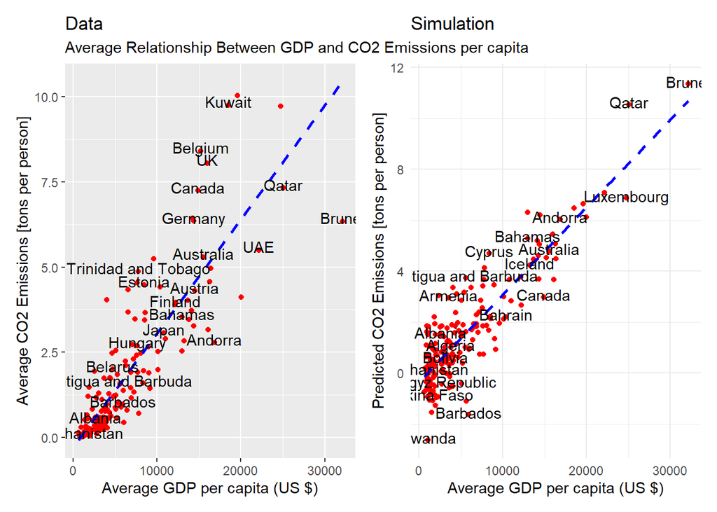

```r
average_data <- merged_data |>
  group_by(country) |>
  summarise(avg_GDP = mean(GDP, na.rm = TRUE),
            avg_CO2_emissions = mean(CO2,
                                     na.rm = TRUE)
            )|>
  filter(across(everything(), ~is.na(.) == 0))

noise<-function(x, sd){
  x + rnorm(length(x),mean=0,sd)
}

CO2_predict<-predict(regression_model)
CO2_sigma<-sigma(regression_model)
model_w_noise<-noise(CO2_predict, CO2_sigma)

simulation<- tibble(sim_CO2 = model_w_noise)

pred_obs_df<-average_data|>
  mutate(pred_CO2=simulation$sim_CO2)

side_by_side_2 = pred_obs_df |>
  ggplot(aes(x = avg_GDP,
             y = pred_CO2,
             label = country)
         ) +
  geom_point(color = "red") +
  geom_smooth(method = "lm",
              se = FALSE,
              color = "blue",
              linetype = "dashed") +
  geom_text(nudge_x = 0.1,
            nudge_y = 0.1,
            check_overlap = TRUE) +
  labs(title = "Simulation",
       x = "Average GDP per capita (US $)",
       y = "Predicted CO2 Emissions [tons per person]") +
  theme_minimal()

# Arrange plots side by side
side_by_side_1 + side_by_side_2 + plot_layout(ncol = 2)
```

```r
# Display the summary of the regression model
summary(regression_model)
```

```
Call:
lm(formula = avg_CO2_emissions ~ avg_GDP, data = average_data)

Residuals:
    Min      1Q  Median      3Q     Max
-4.1019 -0.4351 -0.1124  0.1127  3.8578

Coefficients:
              Estimate Std. Error t value Pr(>|t|)
(Intercept) -2.863e-01  1.038e-01  -2.758  0.00638 **
avg_GDP      3.342e-04  1.339e-05  24.952  < 2e-16 ***
---
Signif. codes:  0 '***' 0.001 '**' 0.01 '*' 0.05 '.' 0.1 ' ' 1

Residual standard error: 0.9975 on 191 degrees of freedom
Multiple R-squared:  0.7652,    Adjusted R-squared:  0.764
F-statistic: 622.6 on 1 and 191 DF,  p-value: < 2.2e-16
```

```r
broom::tidy(regression_model)
```

```
# A tibble: 2 × 5
  term         estimate std.error statistic  p.value
  <chr>           <dbl>     <dbl>     <dbl>    <dbl>
1 (Intercept) -0.286    0.104         -2.76 6.38e- 3
2 avg_GDP      0.000334 0.0000134     25.0  5.17e-62
```